# Week 10 Assignment — Independent Optimal Answers

These answers were developed independently from the assignment and its data, without consulting an existing answer key or assignment solution script. Questions 1–9 use the ordinary regression requested in the assignment. Question 10 examines the limitations of treating repeated observations as independent. The AI prompts below are model prompts, not a fabricated Copilot transcript.

## Question 1 — Import and summarize the data

```r
library(estimatr)
library(GGally)
library(ggplot2)
library(psych)
library(summarytools)

assign10 <- read.csv("https://raw.githubusercontent.com/craigenders/psych250a/main/data/assignment10.csv")
dfSummary(assign10)
```

```
## Data Frame Summary
## assign10
## Dimensions: 2701 x 9
## Duplicates: 0
##
## ---------------------------------------------------------------------------------------------------------------
## No   Variable        Stats / Values            Freqs (% of Valid)    Graph                 Valid      Missing
## ---- --------------- ------------------------- --------------------- --------------------- ---------- ---------
## 1    Person          Mean (sd) : 66.6 (38.2)   131 distinct values   : . . . . . . . . :   2701       0
##      [integer]       min < med < max:                                : : : : : : : : : :   (100.0%)   (0.0%)
##                      1 < 66 < 132                                    : : : : : : : : : :
##                      IQR (CV) : 66 (0.6)                             : : : : : : : : : :
##                                                                      : : : : : : : : : :
##
## 2    Day             Mean (sd) : 9.9 (6)       21 distinct values    :                     2701       0
##      [integer]       min < med < max:                                : . . . . . .         (100.0%)   (0.0%)
##                      0 < 10 < 20                                     : : : : : : : : : :
##                      IQR (CV) : 10 (0.6)                             : : : : : : : : : :
##                                                                      : : : : : : : : : :
##
## 3    Pain            Mean (sd) : 3.6 (2.2)     0 : 216 ( 8.0%)       I                     2701       0
##      [integer]       min < med < max:          1 : 253 ( 9.4%)       I                     (100.0%)   (0.0%)
##                      0 < 3 < 9                 2 : 461 (17.1%)       III
##                      IQR (CV) : 3 (0.6)        3 : 472 (17.5%)       III
##                                                4 : 452 (16.7%)       III
##                                                5 : 307 (11.4%)       II
##                                                6 : 231 ( 8.6%)       I
##                                                7 : 185 ( 6.8%)       I
##                                                8 :  81 ( 3.0%)
##                                                9 :  43 ( 1.6%)
##
## 4    Sleep           Mean (sd) : 5.4 (2.1)     0 :  72 ( 2.7%)                             2701       0
##      [integer]       min < med < max:          1 :  39 ( 1.4%)                             (100.0%)   (0.0%)
##                      0 < 6 < 9                 2 : 152 ( 5.6%)       I
##                      IQR (CV) : 3 (0.4)        3 : 266 ( 9.8%)       I
##                                                4 : 310 (11.5%)       II
##                                                5 : 452 (16.7%)       III
##                                                6 : 431 (16.0%)       III
##                                                7 : 520 (19.3%)       III
##                                                8 : 325 (12.0%)       II
```

[output cut: 15 more lines]

```
##                      IQR (CV) : 1 (0.2)                                  : : : : : : .
##                                                                      .   : : : : : : : :
##
## 8    Catastrophize   Mean (sd) : 1.8 (0.7)     37 distinct values            :             2701       0
##      [numeric]       min < med < max:                                      . :             (100.0%)   (0.0%)
##                      0.2 < 1.8 < 3.7                                     : : : . .
##                      IQR (CV) : 0.8 (0.4)                                : : : : :
##                                                                      : : : : : : : : . .
##
## 9    Stress          Mean (sd) : 1 (0.6)       20 distinct values          :               2701       0
##      [numeric]       min < med < max:                                  :   :               (100.0%)   (0.0%)
##                      0 < 0.9 < 2.9                                     :   :
##                      IQR (CV) : 0.7 (0.6)                              :   :     .
##                                                                      : : : : : : :
## ---------------------------------------------------------------------------------------------------------------
```

**Data access note:** The assignment URL returned HTTP 404 when these answers were prepared. The analysis uses the local `assignment10.csv` in the course Git repository. The student-facing import code above is shown as requested but is not executed in this instructor report.

**Verification:** The data contain 2,701 daily observations from 131 participants, with no missing entries in the nine variables. Participant IDs extend to 132, but there are only 131 distinct IDs. Sleep and pain both have observed ranges of 0–9. Keep `Female` coded numerically as 0 and 1 for the requested point-biserial correlation.

## Question 2 — Scatterplot and correlation matrices

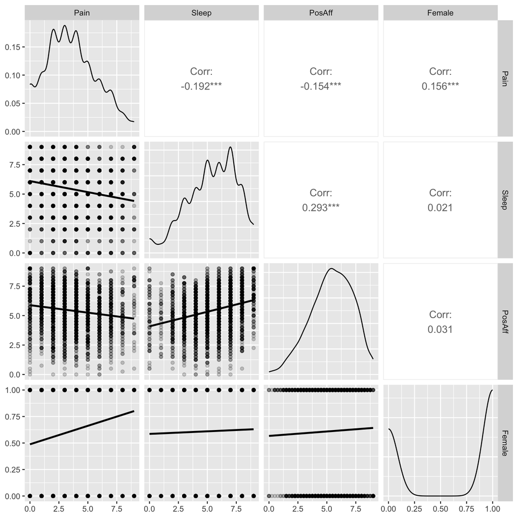

```r
vars2corr <- assign10[, c("Pain", "Sleep", "PosAff", "Female")]
ggpairs(vars2corr,
        upper=list(continuous=wrap("cor", size=4)),
        lower=list(continuous=wrap("smooth", method="lm", se=FALSE, alpha=0.2)),
        diag=list(continuous=wrap("densityDiag")))
```

```r
print(corr.test(vars2corr), short=FALSE)
```

```
## Call:corr.test(x = vars2corr)
## Correlation matrix
##         Pain Sleep PosAff Female
## Pain    1.00 -0.19  -0.15   0.16
## Sleep  -0.19  1.00   0.29   0.02
## PosAff -0.15  0.29   1.00   0.03
## Female  0.16  0.02   0.03   1.00
## Sample Size
## [1] 2701
## Probability values (Entries above the diagonal are adjusted for multiple tests.)
##        Pain Sleep PosAff Female
## Pain      0  0.00   0.00   0.00
## Sleep     0  0.00   0.00   0.27
## PosAff    0  0.00   0.00   0.22
## Female    0  0.27   0.11   0.00
##
##  Confidence intervals based upon normal theory.  To get bootstrapped values, try cor.ci
##             raw.lower raw.r raw.upper raw.p lower.adj upper.adj
## Pain-Sleep      -0.23 -0.19     -0.16  0.00     -0.24     -0.14
## Pain-PsAff      -0.19 -0.15     -0.12  0.00     -0.20     -0.11
## Pain-Femal       0.12  0.16      0.19  0.00      0.11      0.20
## Sleep-PsAff      0.26  0.29      0.33  0.00      0.25      0.34
## Sleep-Femal     -0.02  0.02      0.06  0.27     -0.02      0.06
## PsAff-Femal     -0.01  0.03      0.07  0.11     -0.01      0.07
```

The correlations with pain are −.192 for sleep, −.154 for positive affect, and .156 for female sex. Because sex is binary, its scatterplots have two bands of points rather than a continuous range. The matrix describes associations across diary rows; its usual significance tests do not account for clustering by participant.

## Question 3 — Which predictor gives the highest R²?

Sleep would produce the highest R². In a simple linear regression with an intercept, R² equals the squared Pearson correlation between the predictor and outcome. Sleep has the largest correlation with pain in absolute value: |−.192| exceeds |−.154| for positive affect and |.156| for sex. Squaring these correlations yields R² values of approximately .0369, .0237, and .0243, respectively. Thus, sleep would account for about 3.7% of the variation in daily pain ratings. Its negative sign describes direction and does not reduce the amount of variation explained.

## Question 4 — Interpret the sleep–pain correlation

The correlation between sleep quality and pain is r = −.192, a weak negative linear association. Higher sleep scores indicate better sleep, so observations with better sleep quality the previous night tend to have lower daily pain ratings. The association is modest: pain ratings still vary considerably at any given sleep score. This correlation does not establish that better sleep causes less pain, and pooling daily observations does not distinguish differences between participants from changes within the same participant.

## Question 5 — Interpret the sex–pain correlation

The point-biserial correlation between Female and Pain is r = .156, a weak positive association. Because Female is coded 0 for men and 1 for women, the positive sign indicates that women have higher pain ratings on average than men. Across the diary observations, the mean pain rating is approximately 3.84 for women and 3.15 for men. The small correlation indicates substantial overlap rather than a clear separation between the sexes. These are averages over daily records, so participants with more records receive more weight.

## Question 6 — Plot and fit the regression

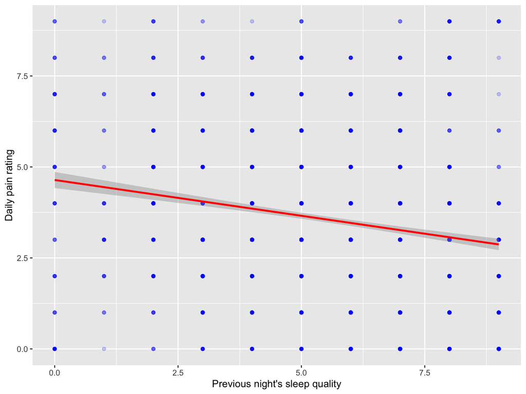

```r
ggplot(assign10, aes(x=Sleep, y=Pain)) +
  geom_point(color="blue", alpha=0.2) +
  geom_smooth(method="lm", color="red") +
  labs(x="Previous night's sleep quality", y="Daily pain rating")
```

```r
results <- lm(Pain ~ Sleep, data=assign10)
summary(results)
```

```
##
## Call:
## lm(formula = Pain ~ Sleep, data = assign10)
##
## Residuals:
##    Min     1Q Median     3Q    Max
## -4.641 -1.461 -0.248  1.539  6.129
##
## Coefficients:
##             Estimate Std. Error t value Pr(>|t|)
## (Intercept)  4.64139    0.11280   41.15   <2e-16 ***
## Sleep       -0.19672    0.01933  -10.18   <2e-16 ***
## ---
## Signif. codes:  0 '***' 0.001 '**' 0.01 '*' 0.05 '.' 0.1 ' ' 1
##
## Residual standard error: 2.139 on 2699 degrees of freedom
## Multiple R-squared:  0.03694,    Adjusted R-squared:  0.03658
## F-statistic: 103.5 on 1 and 2699 DF,  p-value: < 2.2e-16
```

```r
confint(results)
```

```
##                  2.5 %     97.5 %
## (Intercept)  4.4201992  4.8625849
## Sleep       -0.2346252 -0.1588049
```

The fitted equation is predicted Pain = 4.6414 − 0.1967 × Sleep. The ordinary regression reports an intercept SE of 0.1128 and slope SE of 0.01933; the slope t statistic is −10.175 with 2,699 df, p < .001. R² = .03694. The ordinary 95% confidence intervals are [4.4202, 4.8626] for the intercept and [−0.2346, −0.1588] for the slope. These uncertainty estimates rely on assumptions examined in Question 10.

## Question 7 — Explain the shaded confidence band

**Model AI prompt:**

> I am analyzing a chronic-pain diary study. My R data frame, assign10, contains 2,701 daily records from 131 participants, each contributing up to 21 days. Pain is a daily pain rating from 0 to 9, with higher values indicating more pain. Sleep is the previous night’s sleep quality from 0 to 9, with higher values indicating better sleep. I fit lm(Pain ~ Sleep, data=assign10) and plotted ggplot(assign10, aes(x=Sleep, y=Pain)) + geom_point() + geom_smooth(method=“lm”). Explain what the default shaded band around this regression line represents, why it is narrow near the middle and wider at the extremes, and how it connects to standard errors, sampling variability, and 95% confidence intervals. Distinguish uncertainty about average pain from variation in individual pain ratings. Explain the graph produced by this ordinary regression, and identify any caveat introduced by repeated observations from the same people.

**Model documentation paragraph:**

The shaded band shows a 95% confidence interval for the population’s average pain rating at each sleep-quality score, as estimated by the fitted regression. It describes uncertainty about the average relationship; it does not indicate where 95% of individual pain ratings fall. The line is estimated most precisely near the average sleep score, about 5.43. Farther from that value, uncertainty about the slope contributes more to uncertainty about the predicted average, so the standard error increases and the band widens. This is the same principle used in other confidence intervals: a larger standard error produces a wider interval. Under the model’s assumptions, repeatedly sampling data and constructing an interval at a particular sleep score would produce intervals that contain the true average pain at that score about 95% of the time. This is a pointwise statement, not a claim that the entire band covers the true line with 95% probability. Here, the plotted band uses ordinary regression standard errors that do not account for repeated measurements within people, so its nominal coverage may be inaccurate.

**Numerical check:** At the average sleep score, the ordinary interval is approximately [3.492, 3.653]; at Sleep = 0 it is [4.420, 4.863]; and at Sleep = 9 it is [2.713, 3.028].

## Question 8 — Interpret and evaluate the intercept

The intercept is 4.6414. It is the predicted average daily pain rating for observations in which the previous night’s sleep-quality score is 0. This is meaningful here because 0 is a valid value on the 0–9 sleep scale and actually occurs in the data: 72 observations have Sleep = 0. Thus, the intercept is not an extrapolation to an impossible or unobserved predictor value. It refers to the lowest rated sleep quality, not to zero hours of sleep. It is an estimated average pain rating rather than a prediction that every person with this sleep score has pain of 4.64.

## Question 9 — Interpret the slope

The slope is −0.1967. A one-point increase in the previous night’s sleep-quality rating is associated with a predicted decrease of approximately 0.197 points in average daily pain, measured on the 0–9 pain scale. For example, the predicted average pain difference between sleep scores of 4 and 5 is about 0.197 points, with lower pain at the better sleep score. This is an association rather than an established causal effect. Because the regression pools repeated daily records, it does not isolate how a particular person’s pain changes when that person sleeps better than usual.

## Question 10 — Investigate the independence assumption

### Model sequence of AI prompts

**Initial prompt:**

> A reviewer questions my ordinary regression because each participant contributes repeated daily observations. The data frame assign10 contains 2,701 records from 131 people, with up to 21 observations each. Person identifies participants; Day identifies days 0–20; Pain is daily pain severity; and Sleep is the previous night’s sleep quality. Both ratings range from 0 to 9. I fit lm(Pain ~ Sleep, data=assign10). What regression assumption is the reviewer concerned about? Explain the possible consequences for coefficients, standard errors, confidence intervals, and p-values, distinguishing what necessarily follows from what depends on the nature of the dependence.

**Follow-up prompt:**

> What would need to be true about the participants and their day-to-day deviations from the fitted regression for the independence assumption to hold despite the repeated measurements? Distinguish independent participants from independent observations within each participant. Explain why including sleep as a predictor might or might not remove the dependence.

**Diagnostic-code prompt:**

> Help me assess this concern empirically. Provide R code using only base R, estimatr, GGally, ggplot2, psych, and summarytools. Use assign10 and the variables Person, Day, Pain, and Sleep. Verify the number of participants and observations per person. Examine whether residuals from lm(Pain ~ Sleep, data=assign10) cluster by participant. Include an interpretable numerical measure and a graph, and explain the limitations of the diagnostics. There are unequal numbers of observations per person. Do not treat a significant association between sleep and pain as evidence that errors are independent.

**Follow-up after running the code:**

> The data contain 2,701 observations from 131 people; 123 people have 21 observations, and the remaining people have 4–20. A one-way decomposition of the ordinary regression residuals by Person gives between-person MS = 54.326 and within-person MS = 2.057. An unequal-group-size method-of-moments residual ICC is approximately .552. Participant mean residuals range from −3.252 to 5.826. Interpret this evidence and its limitations. What should I tell the reviewer about ordinary regression uncertainty estimates, and what analysis could address dependence? Distinguish a correction to standard errors from an analysis that separates within-person and between-person sleep associations.

### Diagnostic code

This is one defensible investigation, not the only acceptable approach. The ICC below is an approximate descriptive random-intercept diagnostic calculated from residuals of the fitted regression. It is not a full fitted multilevel model or a test of every form of dependence.

```r
diag_data <- assign10
# Fit explicitly so this code can be read independently of Question 6.
ordinary_fit <- lm(Pain ~ Sleep, data=diag_data)
diag_data$residual <- resid(ordinary_fit)

n_by_person <- table(diag_data$Person)
c(observations=nrow(diag_data), participants=length(n_by_person))
```

```
## observations participants
##         2701          131
```

```r
table(observations_per_person=as.integer(n_by_person))
```

```
## observations_per_person
##   4  10  13  15  17  19  20  21
##   1   1   1   1   1   1   2 123
```

```r
# Estimate the clustering of residuals by person from a one-way decomposition.
residual_anova <- anova(lm(residual ~ factor(Person), data=diag_data))
MS_between <- residual_anova$`Mean Sq`[1]
MS_within <- residual_anova$`Mean Sq`[2]
K <- length(n_by_person)
N <- sum(n_by_person)
# Effective group size for unequal numbers of observations per participant.
n0 <- (N - sum(n_by_person^2)/N)/(K - 1)
between_variance <- (MS_between - MS_within)/n0
residual_ICC <- between_variance/(between_variance + MS_within)
c(MS_between=MS_between, MS_within=MS_within,
  residual_ICC=residual_ICC)
```

```
##   MS_between    MS_within residual_ICC
##   54.3262006    2.0571455    0.5520547
```

```r
person_means <- aggregate(residual ~ Person, data=diag_data, FUN=mean)
range(person_means$residual)
```

```
## [1] -3.252068  5.826159
```

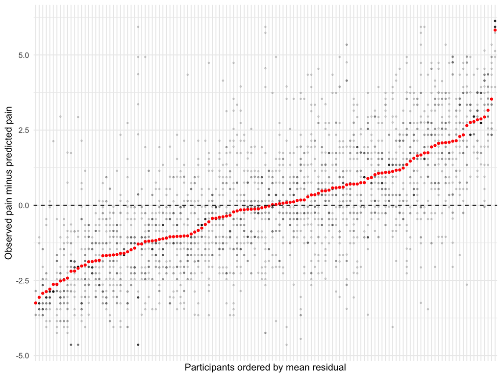

```r
# Order people by their mean residual to make systematic differences visible.
ordered_ids <- person_means$Person[order(person_means$residual)]
diag_data$person_order <- factor(diag_data$Person, levels=ordered_ids)
ggplot(diag_data, aes(x=person_order, y=residual)) +
  geom_point(alpha=0.15, size=0.6) +
  stat_summary(fun=mean, geom="point", color="red", size=1) +
  geom_hline(yintercept=0, linetype="dashed") +
  labs(x="Participants ordered by mean residual",
       y="Observed pain minus predicted pain") +
  theme_minimal() +
  theme(axis.text.x=element_blank(), axis.ticks.x=element_blank())
```

### Model response to the reviewer

The reviewer’s concern is valid. Ordinary regression’s usual standard errors assume that the errors for different observations are uncorrelated, conditional on the predictor. Having independent participants does not make the repeated observations within each participant independent. For the ordinary independence assumption to hold here, knowing one day’s deviation from predicted pain would need to provide no information about that person’s deviations on other days. This would require no remaining shared person-level influences or temporal dependence after accounting for sleep. Participants can differ in their sleep and pain levels without necessarily violating the error assumption; the issue is dependence that remains after the fitted mean relationship is taken into account.

Our investigation indicates substantial residual clustering. There are 2,701 records from only 131 participants, 123 of whom contribute all 21 daily measurements. After fitting pain as a function of sleep, the between-person residual mean square is 54.326, compared with a within-person mean square of 2.057. An approximate residual intraclass correlation is .552, indicating substantial shared residual variation among observations from the same participant. The graph also shows that some participants’ pain ratings are systematically above the regression’s predictions and others’ are systematically below them; participant mean residuals range from −3.252 to 5.826 points. This is evidence that including sleep alone has not removed the dependence. The ICC summarizes persistent person-level clustering; it does not rule out additional serial dependence across days.

Ignoring positive within-person dependence can underestimate standard errors, produce overly narrow confidence intervals, and make p-values too small. The precise effect on the slope’s uncertainty depends on the dependence structure and on how sleep varies within and between people, so the ordinary slope SE of .01933 and its p-value should not be assumed valid. Dependence alone does not necessarily bias the slope estimate, but a pooled slope can combine distinct within-person and between-person associations and can be affected by unmodeled person-level differences related to sleep. To address the concern, we could fit a multilevel regression with observations nested within participants, initially including a participant random intercept and assessing whether additional temporal dependence or random slopes are needed. If the research goal is to distinguish better-than-usual sleep from differences between people, we should separately model person-mean sleep and daily deviations from that mean. Alternatively, participant-clustered robust standard errors, such as CR2 standard errors with Person as the cluster in estimatr, can address inference for the pooled regression while retaining its coefficients, assuming independent participants. Ordinary heteroscedasticity-robust standard errors alone would not account for within-person dependence.

## Question 11 — Chat log

This ungraded item requires the student’s actual, complete Copilot conversation for Questions 7 and 10. There is no substantive statistical answer and no substitute transcript should be invented. The model prompts above illustrate the requested process; they are not evidence that a student completed it.